# 451_pa1_jump_start_v001

## 451 Financial Engineering: Programming Assignment 1

### Thomas W. Miller, June 18, 2025

---

## Overview

A model for predicting the direction of daily returns sets the stage for testing the predictive utility of additional features. The domain of potential features or leading indicators is wide, including those associated with other price series, economic indicators, international events, securities filings, analyst and news reports, and media measures.

### Import Libraries

We draw on Python packages for data manipulation and modeling. Most important are Polars, a high-performance alternative to Pandas for data manipulation, and Scikit-Learn for machine learning study design and modeling algorithms.

```python
import os
# Ignore warnings
import warnings
warnings.filterwarnings('ignore')
warnings.simplefilter(action='ignore', category=FutureWarning)

# Import Python Packages for data manipulation, data pipelines, and databases
import numpy as np
import pyarrow # foundation for polars
import polars as pl # DataFrame work superior to Pandas

# Plotting
import matplotlib.pyplot as plt
# Display static plots directly in the notebook output
%matplotlib inline
# create stylized visualizations, including heat maps
import seaborn as sns

# Preprocessing
from sklearn.preprocessing import MinMaxScaler, StandardScaler
from sklearn.pipeline import Pipeline
from sklearn.model_selection import (RandomizedSearchCV,
                                    TimeSeriesSplit)
from sklearn.model_selection import cross_validate

# utilized in all possible subsets classification work
from sklearn.linear_model import LogisticRegression
from sklearn.metrics import log_loss

# needed for randomized search
from sklearn.model_selection import RandomizedSearchCV
from scipy.stats import randint, uniform

# metrics in xgboost tuning and final model evaluation
from sklearn.metrics import (accuracy_score,
                             classification_report,
                             roc_curve,
                             roc_auc_score,
                             RocCurveDisplay,
                             ConfusionMatrixDisplay,
                             confusion_matrix,
                             precision_score,
                             recall_score,
                             f1_score
                            )

# XGBoost Package... more complete than SciKit-Learn boosting methods
import xgboost as xgb
from xgboost import XGBRegressor, XGBClassifier, plot_importance

# import yfinance as yf  # used earlier to obtain the price series
# import yfinance as yf

import warnings
# Suppress warnings for cleaner output
warnings.filterwarnings('ignore')
```

### Retrieve Data

In previous work, we retrieved price data for WTI from Yahoo Finance. The code is shown in the next commented-out cell.

```python
'''
Previous work to retrieve data from Yahoo Finance

symbol = 'WTI'
start_date = '2000-01-01'
end_date = '2025-05-27'

symbol = 'WTI'
ticker = yf.Ticker(symbol)
historical_data = ticker.history(start = start_date, end = end_date, period = '1mo')
print(historical_data)

print("type of historical_data", type(historical_data))

historical_data.to_csv("wti_historical_data.csv")
'''
```

```
'\nPrevious work to retrieve data from Yahoo Finance\n\nsymbol = \'WTI\'\nstart_date = \'2000-01-01\'\nend_date = \'2025-05-27\'\n\nsymbol = \'WTI\'\nticker = yf.Ticker(symbol)\nhistorical_data = ticker.history(start = start_date, end = end_date, period = \'1mo\')\nprint(historical_data)\n\nprint("t…
```

### Polars DataFrame Development

The following code cell demonstrates Polars use with the time series DataFrame for our selected market/ticker, WTI.

```python
wti = pl.read_csv("msds_getdata_yfinance_aapl.csv", try_parse_dates=True)

# check the original schema
print(wti.schema)

# drop useless columns Dividends and StockSplits
wti = wti.drop(['Dividends', 'Stock Splits'])

# create lag price features
wti = wti.with_columns((pl.col('Close')).shift().alias('CloseLag1'))
wti = wti.with_columns((pl.col('CloseLag1')).shift().alias('CloseLag2'))
wti = wti.with_columns((pl.col('CloseLag2')).shift().alias('CloseLag3'))

# create high-minus-low (HML) for day and its lags
wti = wti.with_columns((pl.col('High') - pl.col('Low')).alias('HML'))
wti = wti.with_columns((pl.col('HML')).shift().alias('HMLLag1'))
wti = wti.with_columns((pl.col('HMLLag1')).shift().alias('HMLLag2'))
wti = wti.with_columns((pl.col('HMLLag2')).shift().alias('HMLLag3'))

# create a net change for the day as the open minus closing price OMC
# also create the corresponding lag metrics
wti = wti.with_columns((pl.col('Open') - pl.col('Close')).alias('OMC'))
wti = wti.with_columns((pl.col('OMC')).shift().alias('OMCLag1'))
wti = wti.with_columns((pl.col('OMCLag1')).shift().alias('OMCLag2'))
wti = wti.with_columns((pl.col('OMCLag2')).shift().alias('OMCLag3'))

# create volume lag metrics
wti = wti.with_columns((pl.col('Volume')).shift().alias('VolumeLag1'))
wti = wti.with_columns((pl.col('VolumeLag1')).shift().alias('VolumeLag2'))
wti = wti.with_columns((pl.col('VolumeLag2')).shift().alias('VolumeLag3'))

# compute 10-day exponential moving averages of closing prices
# compute acround CloseLag1 to avoid any "leakage" in explanatory variable set
# note also the 10-day buffer between train and test in time-series cross-validation
wti = wti.with_columns((pl.col('CloseLag1').ewm_mean(half_life=1,ignore_nulls=True)).alias('CloseEMA2'))
wti = wti.with_columns((pl.col('CloseLag1').ewm_mean(half_life=2,ignore_nulls=True)).alias('CloseEMA4'))
wti = wti.with_columns((pl.col('CloseLag1').ewm_mean(half_life=4,ignore_nulls=True)).alias('CloseEMA8'))

# log daily returns
wti = wti.with_columns(np.log(pl.col('Close')/pl.col('CloseLag1')).alias('LogReturn'))

# set volume features to Float64 for subsequent use in Numpy arrays
wti = wti.with_columns(
    pl.col('Volume').cast(pl.Float64).round(0),
    pl.col('VolumeLag1').cast(pl.Float64).round(0),
    pl.col('VolumeLag2').cast(pl.Float64).round(0),
    pl.col('VolumeLag3').cast(pl.Float64).round(0),
    )

# round other features to three decimal places for reporting and subsequent analytics
wti = wti.with_columns(
    pl.col('Open').round(3),
    pl.col('High').round(3),
    pl.col('Low').round(3),
    pl.col('Close').round(3),
    pl.col('CloseLag1').round(3),
    pl.col('CloseLag2').round(3),
    pl.col('CloseLag3').round(3),
    pl.col('HML').round(3),
    pl.col('HMLLag1').round(3),
    pl.col('HMLLag2').round(3),
    pl.col('HMLLag3').round(3),
    pl.col('OMC').round(3),
    pl.col('OMCLag1').round(3),
    pl.col('OMCLag2').round(3),
    pl.col('OMCLag3').round(3),
    pl.col('CloseEMA2').round(3),
    pl.col('CloseEMA4').round(3),
    pl.col('CloseEMA8').round(3))

# define binary target/response 1 = market price up since previous day, 0 = even or down
wti = wti.with_columns(pl.when(pl.col('LogReturn')>0.0).then(pl.lit(1)).otherwise(pl.lit(0)).alias('Target'))

print(wti.schema)

# save to external comma-delimited text file for checking calculations in Excel
wti.write_csv("aapl-with-computed-features.csv")
```

```
Schema({'Date': Datetime(time_unit='us', time_zone='UTC'), 'Open': Float64, 'High': Float64, 'Low': Float64, 'Close': Float64, 'Volume': Int64, 'Dividends': Float64, 'Stock Splits': Float64})
Schema({'Date': Datetime(time_unit='us', time_zone='UTC'), 'Open': Float64, 'High': Float64, 'Low': Float64, 'Close': Float64, 'Volume': Float64, 'CloseLag1': Float64, 'CloseLag2': Float64, 'CloseLag3': Float64, 'HML': Float64, 'HMLLag1': Float64, 'HMLLag2': Float64, 'HMLLag3': Float64, 'OMC': Float…
```

### Descriptive Statistics for Price Features

```python
# Drop the rows with null values such as the initial lag rows
wti = wti.drop_nulls()

# Descriptive statistics
wtiStatistics = wti.drop('Date').describe()

print(wtiStatistics.columns)

wtiStatisticsToPrint = wtiStatistics.transpose(include_header=True).drop(['column_1', 'column_5', 'column_7'])

print(wtiStatisticsToPrint.schema)

with pl.Config(
    tbl_rows = 60,
    tbl_width_chars = 200,
    tbl_cols = -1,
    float_precision = 3,
    tbl_hide_dataframe_shape = True,
    tbl_hide_column_data_types = True):
    print(wtiStatisticsToPrint)
```

```
['statistic', 'Open', 'High', 'Low', 'Close', 'Volume', 'CloseLag1', 'CloseLag2', 'CloseLag3', 'HML', 'HMLLag1', 'HMLLag2', 'HMLLag3', 'OMC', 'OMCLag1', 'OMCLag2', 'OMCLag3', 'VolumeLag1', 'VolumeLag2', 'VolumeLag3', 'CloseEMA2', 'CloseEMA4', 'CloseEMA8', 'LogReturn', 'Target']
Schema({'column': String, 'column_0': String, 'column_2': String, 'column_3': String, 'column_4': String, 'column_6': String, 'column_8': String})
┌────────────┬──────────┬───────────────────────┬──────────────────────┬─────────────────────┬──────────────────────┬─────────────────────┐
│ column     ┆ column_0 ┆ column_2              ┆ column_3             ┆ column_4            ┆ column_6             ┆ column_8            │
╞════════════╪══════════╪═══════════════════════╪══════════════════════╪═════════════════════╪══════════════════════╪═════════════════════╡
│ statistic  ┆ count    ┆ mean                  ┆ std                  ┆ min                 ┆ 50%                  ┆ max                 │
│ Open       ┆ 6468.0   ┆ 46.120921459492884    ┆ 66.03913101568145    ┆ 0.195               ┆ 15.438               ┆ 257.277             │
│ High       ┆ 6468.0   ┆ 46.62360497835498     ┆ 66.76058666021193    ┆ 0.198               ┆ 15.565               ┆ 259.18              │
│ Low        ┆ 6468.0   ┆ 45.64927118119975     ┆ 65.38326269621751    ┆ 0.191               ┆ 15.295               ┆ 256.719             │
│ Close      ┆ 6468.0   ┆ 46.15934817563389     ┆ 66.11080529424646    ┆ 0.197               ┆ 15.456               ┆ 258.104             │
│ Volume     ┆ 6468.0   ┆ 376575420.1298701     ┆ 382245281.2346179    ┆ 23234700.0          ┆ 256450400.0          ┆ 7421640800.0        │
│ CloseLag1  ┆ 6468.0   ┆ 46.12045995670996     ┆ 66.06348423151697    ┆ 0.197               ┆ 15.44                ┆ 258.104             │
│ CloseLag2  ┆ 6468.0   ┆ 46.08124211502783     ┆ 66.01507826336547    ┆ 0.197               ┆ 15.434               ┆ 258.104             │
│ CloseLag3  ┆ 6468.0   ┆ 46.04178014842301     ┆ 65.96579674108862    ┆ 0.197               ┆ 15.402               ┆ 258.104             │
│ HML        ┆ 6468.0   ┆ 0.9743308596165737    ┆ 1.6828296058391077   ┆ 0.003               ┆ 0.248                ┆ 28.65               │
│ HMLLag1    ┆ 6468.0   ┆ 0.9736130179344464    ┆ 1.6822302793937618   ┆ 0.003               ┆ 0.248                ┆ 28.65               │
│ HMLLag2    ┆ 6468.0   ┆ 0.9730426716141       ┆ 1.6819107639464312   ┆ 0.003               ┆ 0.248                ┆ 28.65               │
│ HMLLag3    ┆ 6468.0   ┆ 0.9717379406307978    ┆ 1.679326620793468    ┆ 0.003               ┆ 0.248                ┆ 28.65               │
│ OMC        ┆ 6468.0   ┆ -0.038438620902906624 ┆ 1.184255918501584    ┆ -26.834             ┆ -0.002               ┆ 14.245              │
│ OMCLag1    ┆ 6468.0   ┆ -0.03888883735312308  ┆ 1.1836882313954      ┆ -26.834             ┆ -0.002               ┆ 14.245              │
│ OMCLag2    ┆ 6468.0   ┆ -0.03910636982065553  ┆ 1.1835438453373932   ┆ -26.834             ┆ -0.002               ┆ 14.245              │
│ OMCLag3    ┆ 6468.0   ┆ -0.037911719233147775 ┆ 1.1796223602173967   ┆ -26.834             ┆ -0.002               ┆ 14.245              │
│ VolumeLag1 ┆ 6468.0   ┆ 376689213.86827457    ┆ 382255309.22855794   ┆ 23234700.0          ┆ 256659200.0          ┆ 7421640800.0        │
│ VolumeLag2 ┆ 6468.0   ┆ 376759112.1985158     ┆ 382238776.3871054    ┆ 23234700.0          ┆ 256687200.0          ┆ 7421640800.0        │
│ VolumeLag3 ┆ 6468.0   ┆ 376825636.5337044     ┆ 382229005.0420011    ┆ 23234700.0          ┆ 256737600.0          ┆ 7421640800.0        │
│ CloseEMA2  ┆ 6468.0   ┆ 46.08167764378479     ┆ 66.00575692489888    ┆ 0.198               ┆ 15.387               ┆ 256.574             │
│ CloseEMA4  ┆ 6468.0   ┆ 46.02847387136672     ┆ 65.93281508736574    ┆ 0.201               ┆ 15.35                ┆ 254.548             │
│ CloseEMA8  ┆ 6468.0   ┆ 45.92310621521336     ┆ 65.79490709777113    ┆ 0.204               ┆ 15.207               ┆ 251.687             │
│ LogReturn  ┆ 6468.0   ┆ 0.0008933905509454164 ┆ 0.025164765055830627 ┆ -0.7312478821694488 ┆ 0.000942017395152806 ┆ 0.14261749350102068 │
│ Target     ┆ 6468.0   ┆ 0.5227272727272727    ┆ 0.4995218203482551   ┆ 0.0                 ┆ 1.0                  ┆ 1.0                 │
└────────────┴──────────┴───────────────────────┴──────────────────────┴─────────────────────┴──────────────────────┴─────────────────────┘
```

### Feature List

```python
# Select Features for the Model, exclude current day price variables ... no "leakage"
# note for moving averages, we have excluded the current day, and provide a 10-day gap
# so these may be included in the set
X = wti.drop(['Date', 'LogReturn', 'Target', 'Open', 'High', 'Low', 'Close', 'Volume', 'HML', 'OMC'])
X.head()
```

shape: (5, 15)

| CloseLag1 f64 | CloseLag2 f64 | CloseLag3 f64 | HMLLag1 f64 | HMLLag2 f64 | HMLLag3 f64 | OMCLag1 f64 | OMCLag2 f64 | OMCLag3 f64 | VolumeLag1 f64 | VolumeLag2 f64 | VolumeLag3 f64 | CloseEMA2 f64 | CloseEMA4 f64 | CloseEMA8 f64 |
| --- | --- | --- | --- | --- | --- | --- | --- | --- | --- | --- | --- | --- | --- | --- |
| 0.781 | 0.769 | 0.84 | 0.057 | 0.071 | 0.081 | -0.002 | 0.043 | -0.053 | 7.783216e8 | 5.123776e8 | 5.357968e8 | 0.786 | 0.79 | 0.793 |
| 0.713 | 0.781 | 0.769 | 0.09 | 0.057 | 0.071 | 0.083 | -0.002 | 0.043 | 7.679728e8 | 7.783216e8 | 5.123776e8 | 0.747 | 0.76 | 0.768 |
| 0.747 | 0.713 | 0.781 | 0.041 | 0.09 | 0.057 | -0.023 | 0.083 | -0.002 | 4.607344e8 | 7.679728e8 | 7.783216e8 | 0.747 | 0.755 | 0.762 |
| 0.734 | 0.747 | 0.713 | 0.056 | 0.041 | 0.09 | 0.032 | -0.023 | 0.083 | 5.05064e8 | 4.607344e8 | 7.679728e8 | 0.74 | 0.748 | 0.755 |
| 0.696 | 0.734 | 0.747 | 0.067 | 0.056 | 0.041 | 0.024 | 0.032 | -0.023 | 4.415488e8 | 5.05064e8 | 4.607344e8 | 0.718 | 0.731 | 0.742 |

### Examine the Distribution of LogReturn Values

```python
# Define and examine the target for regression model development
print(wti['LogReturn'].describe())

y = np.array(wti['LogReturn'])
```

```
shape: (9, 2)
┌────────────┬───────────┐
│ statistic  ┆ value     │
│ ---        ┆ ---       │
│ str        ┆ f64       │
╞════════════╪═══════════╡
│ count      ┆ 6468.0    │
│ null_count ┆ 0.0       │
│ mean       ┆ 0.000893  │
│ std        ┆ 0.025165  │
│ min        ┆ -0.731248 │
│ 25%        ┆ -0.009849 │
│ 50%        ┆ 0.000942  │
│ 75%        ┆ 0.012469  │
│ max        ┆ 0.142617  │
└────────────┴───────────┘
```

### Standardize All Features

Standardization is carried out for the complete set of features.

```python
# Standardize features
featureNames = X.columns
print("Feature names correspond to Numpy array columns:",featureNames)
scaler = StandardScaler()
X = scaler.fit_transform(np.array(X))
```

```
Feature names correspond to Numpy array columns: ['CloseLag1', 'CloseLag2', 'CloseLag3', 'HMLLag1', 'HMLLag2', 'HMLLag3', 'OMCLag1', 'OMCLag2', 'OMCLag3', 'VolumeLag1', 'VolumeLag2', 'VolumeLag3', 'CloseEMA2', 'CloseEMA4', 'CloseEMA8']
```

### Target Definition for Classification (Target)

Identify the binary target variable for model development.

```python
# Define and examine the target for classification model development
print(wti['Target'].value_counts())

y = np.array(wti['Target'])
```

```
shape: (2, 2)
┌────────┬───────┐
│ Target ┆ count │
│ ---    ┆ ---   │
│ i32    ┆ u32   │
╞════════╪═══════╡
│ 0      ┆ 3087  │
│ 1      ┆ 3381  │
└────────┴───────┘
```

### Feature Selection Using All Possible Classifications

We draw on traditional applied statistis, selecting the best combination of features using the Akaike Information Criterion (AIC).

```python
import numpy as np
from itertools import chain, combinations
from joblib import Parallel, delayed
from sklearn.linear_model import LogisticRegression
from sklearn.metrics import log_loss
import polars as pl

# Ensure dense, contiguous arrays once
X_np = np.asarray(X, dtype=np.float64, order="C")
y_np = np.asarray(y, dtype=np.int32)

# fast AIC helper (no DF ops inside)
def aic_for_cols(cols):
    if len(cols) == 0:
        return None
    Xc = X_np[:, cols]                 # advanced indexing copy is fine here
    model = LogisticRegression(solver="lbfgs", max_iter=500)  # stable & fast for binary
    model.fit(Xc, y_np)
    ll = -log_loss(y_np, model.predict_proba(Xc)) * len(y_np)
    k  = Xc.shape[1] + 1
    return (cols, 2*k - 2*ll)

# generator for all non-empty subsets
def powerset_indices(n):
    s = list(range(n))
    return chain.from_iterable(combinations(s, r) for r in range(1, n+1))

subs_iter = list(powerset_indices(X_np.shape[1]))  # if this is too big, see option B below

# parallel compute (adjust n_jobs as you like)
results = Parallel(n_jobs=-1, backend="loky", verbose=10)(
    delayed(aic_for_cols)(tuple(cols)) for cols in subs_iter
)

# add dynamic "all features" row (in case you didn’t already include it)
all_cols = tuple(range(X_np.shape[1]))
if all_cols not in subs_iter:
    results.append(aic_for_cols(all_cols))

# build ONE Polars DF at the end (no per-iter concat)
rows = []
trial = 0
for res in results:
    if res is None:
        continue
    cols, aic = res
    trial += 1
    rows.append((trial, " ".join(map(str, cols)), float(aic)))

resultsDataFrame = pl.DataFrame(rows, schema={"trialNumber": pl.Int64,
                                              "features": pl.String,
                                              "aic": pl.Float64})

# inspect top-10
print(resultsDataFrame.sort("aic").head(10))
```

[output not shown]

[output cut: 9 more lines]

[output not shown]

```
shape: (10, 3)
┌─────────────┬──────────┬─────────────┐
│ trialNumber ┆ features ┆ aic         │
│ ---         ┆ ---      ┆ ---         │
│ i64         ┆ str      ┆ f64         │
╞═════════════╪══════════╪═════════════╡
│ 11          ┆ 10       ┆ 8955.399987 │
│ 12          ┆ 11       ┆ 8956.353574 │
│ 5           ┆ 4        ┆ 8956.514125 │
│ 6           ┆ 5        ┆ 8956.541921 │
│ 10          ┆ 9        ┆ 8956.569659 │
│ 15          ┆ 14       ┆ 8956.610835 │
│ 14          ┆ 13       ┆ 8956.61896  │
│ 13          ┆ 12       ┆ 8956.624773 │
│ 2           ┆ 1        ┆ 8956.62516  │
│ 1           ┆ 0        ┆ 8956.627095 │
└─────────────┴──────────┴─────────────┘
```

[output not shown]

```python
print(resultsDataFrame.sort('aic').head(10))
```

```
shape: (10, 3)
┌─────────────┬──────────┬─────────────┐
│ trialNumber ┆ features ┆ aic         │
│ ---         ┆ ---      ┆ ---         │
│ i64         ┆ str      ┆ f64         │
╞═════════════╪══════════╪═════════════╡
│ 11          ┆ 10       ┆ 8955.399987 │
│ 12          ┆ 11       ┆ 8956.353574 │
│ 5           ┆ 4        ┆ 8956.514125 │
│ 6           ┆ 5        ┆ 8956.541921 │
│ 10          ┆ 9        ┆ 8956.569659 │
│ 15          ┆ 14       ┆ 8956.610835 │
│ 14          ┆ 13       ┆ 8956.61896  │
│ 13          ┆ 12       ┆ 8956.624773 │
│ 2           ┆ 1        ┆ 8956.62516  │
│ 1           ┆ 0        ┆ 8956.627095 │
└─────────────┴──────────┴─────────────┘
```

### Selected Feature Subset

```
shape: (7, 7)
┌───────────┬───────────┬───────────┬───────────┬───────────┬───────────┬───────────┐
│ LogReturn ┆ CloseLag1 ┆ CloseLag3 ┆ HMLLag1   ┆ OMCLag2   ┆ OMCLag3   ┆ CloseEMA8 │
│ ---       ┆ ---       ┆ ---       ┆ ---       ┆ ---       ┆ ---       ┆ ---       │
│ f64       ┆ f64       ┆ f64       ┆ f64       ┆ f64       ┆ f64       ┆ f64       │
╞═══════════╪═══════════╪═══════════╪═══════════╪═══════════╪═══════════╪═══════════╡
│ 1.0       ┆ -0.006138 ┆ -0.00615  ┆ -0.009083 ┆ -0.011379 ┆ 0.01737   ┆ -0.005745 │
│ -0.006138 ┆ 1.0       ┆ 0.999516  ┆ 0.818418  ┆ -0.07085  ┆ -0.068977 ┆ 0.999471  │
│ -0.00615  ┆ 0.999516  ┆ 1.0       ┆ 0.820196  ┆ -0.054699 ┆ -0.068473 ┆ 0.999705  │
│ -0.009083 ┆ 0.818418  ┆ 0.820196  ┆ 1.0       ┆ -0.026099 ┆ -0.014652 ┆ 0.823418  │
│ -0.011379 ┆ -0.07085  ┆ -0.054699 ┆ -0.026099 ┆ 1.0       ┆ -0.035226 ┆ -0.060613 │
│ 0.01737   ┆ -0.068977 ┆ -0.068473 ┆ -0.014652 ┆ -0.035226 ┆ 1.0       ┆ -0.059609 │
│ -0.005745 ┆ 0.999471  ┆ 0.999705  ┆ 0.823418  ┆ -0.060613 ┆ -0.059609 ┆ 1.0       │
└───────────┴───────────┴───────────┴───────────┴───────────┴───────────┴───────────┘
```

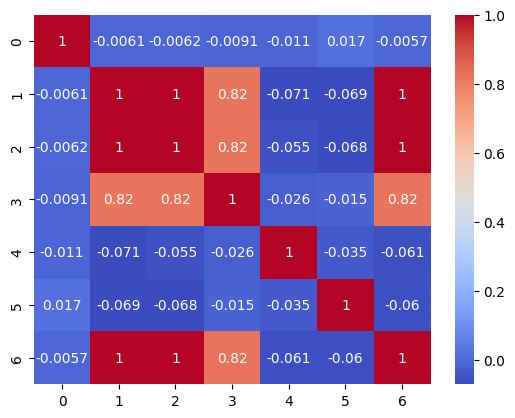

```python
# examine relationships among five selected features, along with LogReturn and CloseLag1
XStudy = wti.select('LogReturn','CloseLag1','CloseLag3','HMLLag1','OMCLag2','OMCLag3','CloseEMA8')

# prepare correlation heat map using seaborn
corrMatrix = XStudy.corr()
print(corrMatrix)
sns.heatmap(corrMatrix, cmap='coolwarm', annot=True)
plt.show()
```

```python
# select subset of five columns as features
X = wti.select('CloseLag3','HMLLag1','OMCLag2','OMCLag3','CloseEMA8')
```

### Define Cross-Validation Training and Test Sets

Recognizing that time series observations are not independent observations, we use Scikit-Learn [TimeSeriesSplit](https://scikit-learn.org/stable/modules/generated/sklearn.model_selection.TimeSeriesSplit.html) for cross-validation.

This cross-validation object is a variation of multi-fold cross-validation for independent observations. In the kth split, it returns first k folds as train set and the (k+1)th fold as test set.

Unlike cross-validation for independent observations, however, successive training sets are supersets of those that come before them. A listing of observation index numbers shows what this means for the time series market data in this demonstration.

```python
# Splitting the datasets into train and test sets
# gap is the number of samples to exclude from
# the end of each train set and before the next test set.
tscv = TimeSeriesSplit(gap=10, n_splits=5)

all_splits = list(tscv.split(X, y))
train_0, test_0 = all_splits[0]
train_1, test_1 = all_splits[1]
train_2, test_2 = all_splits[2]
train_3, test_3 = all_splits[3]
train_4, test_4 = all_splits[4]

# examine the objects created for cross-validation splits
print("type(all_splits):", type(all_splits), " outer list length", len(all_splits))
print()
print("train_0 has",len(train_0),"with indices from ",min(train_0),"to",max(train_0))
print("test_0 has",len(test_0),"with indices from ",min(test_0),"to",max(test_0))
print()
print("train_1 has",len(train_1),"with indices from ",min(train_1),"to",max(train_1))
print("test_1 has",len(test_1),"with indices from ",min(test_1),"to",max(test_1))
print()
print("train_2 has",len(train_2),"with indices from ",min(train_2),"to",max(train_2))
print("test_2 has",len(test_2),"with indices from ",min(test_2),"to",max(test_2))
print()
print("train_3 has",len(train_3),"with indices from ",min(train_3),"to",max(train_3))
print("test_3 has",len(test_3),"with indices from ",min(test_3),"to",max(test_3))
print()
print("train_4 has",len(train_4),"with indices from ",min(train_4),"to",max(train_4))
print("test_4 has",len(test_4),"with indices from ",min(test_4),"to",max(test_4))

# to see all indices we can uncomment these statements
# print("elements of all_splits list of lists,\n shows index numbers for each the five lists")
# print(all_splits)
```

```
type(all_splits): <class 'list'>  outer list length 5

train_0 has 1068 with indices from  0 to 1067
test_0 has 1078 with indices from  1078 to 2155

train_1 has 2146 with indices from  0 to 2145
test_1 has 1078 with indices from  2156 to 3233

train_2 has 3224 with indices from  0 to 3223
test_2 has 1078 with indices from  3234 to 4311

train_3 has 4302 with indices from  0 to 4301
test_3 has 1078 with indices from  4312 to 5389

train_4 has 5380 with indices from  0 to 5379
test_4 has 1078 with indices from  5390 to 6467
```

### Define an Initial Classification Model to Be Evaluated¶

We again select gradient boosting from the XGBoost package, this time defining a classification model to be evaluated. Hyperparameters are retained at defauld settings, except for n_estimators.

```python
model = XGBClassifier(objective='binary:logistic', n_estimators=1000, random_state=2025)
```

### Evaluate a Classification Model Within the Time Series Cross-Validation Design

Prior to executing a full-blown search for the "best" classification model, we test the cross-validation design on a binary classification model, revising code provided in online documentation for Scikit-Learn: [Time-related feature engineerng](https://scikit-learn.org/stable/auto_examples/applications/plot_cyclical_feature_engineering.html#sphx-glr-auto-examples-applications-plot-cyclical-feature-engineering-py). In particular, we define appropriate metrics for assessing classification performance.

```python
def evaluate(model, X, y, cv, model_prop=None, model_step=None):
    cv_results = cross_validate(
        model,
        X,
        y,
        cv=cv,
        scoring=["accuracy"],
        return_estimator=model_prop is not None,
    )
    if model_prop is not None:
        if model_step is not None:
            values = [
                getattr(m[model_step], model_prop) for m in cv_results["estimator"]
            ]
        else:
            values = [getattr(m, model_prop) for m in cv_results["estimator"]]
        print(f"Mean model.{model_prop} = {np.mean(values)}")
    accuracy = -cv_results["test_accuracy"]

    # print used in earlier testing
    # print(
    #    f"Mean Accuracy:     {-accuracy.mean():.3f} +/- {accuracy.std():.3f}\n"
    # )
    return (-accuracy.mean(), accuracy.std())

evaluate(model, X, y, cv=tscv, model_prop="n_estimators")
```

```
Mean model.n_estimators = 1000.0
```

```
(0.487569573283859, 0.015933885382993597)
```

```python
# print results from evaluate
accuracyMean, accuracyStd = evaluate(model, X, y, cv=tscv, model_prop="n_estimators")
print(
        f"Mean Accuracy:     {accuracyMean:.3f} +/- {accuracyStd:.3f}\n"
     )
```

```
Mean model.n_estimators = 1000.0
Mean Accuracy:     0.488 +/- 0.016
```

### Randomized Search for Hyperparameter Settings

We search for effective values on five XGBoost hyperparameters: **max_depth**, **min_child_weight**, **subsample**, **learning_rate**, and **n_estimators**.

```python
# Randomized search to find the best set of hyperparameters

param_dist = {
    'max_depth': randint(3, 10),
    'min_child_weight': randint(1, 10),
    'subsample': uniform(0.5, 1),
    'learning_rate': uniform(0.01, 0.1),
    'n_estimators': randint(100, 1000),
}
xgb_model = xgb.XGBClassifier(objective='binary:logistic', eval_metric='logloss', random_state=2025)

random_search = RandomizedSearchCV(
    estimator=xgb_model,
    param_distributions=param_dist,
    n_iter=100, # Number of parameter settings that are sampled.
    scoring='accuracy',
    cv = TimeSeriesSplit(gap=10, n_splits=5),
    random_state=2025,
    n_jobs=-1 # Use all available cores
)

random_search.fit(X, y)

print("Best parameters:", random_search.best_params_)
print("Best score:", random_search.best_score_)
```

```
Best parameters: {'learning_rate': 0.08964522558051516, 'max_depth': 6, 'min_child_weight': 5, 'n_estimators': 881, 'subsample': 0.8014120643245294}
Best score: 0.4920222634508349
```

### Evaluate the Model

```python
# final model evaluation
finalModel = XGBClassifier(objective='binary:logistic', eval_metric='logloss', random_state=2025,
                          max_depth = 9, min_child_weight = 9, subsample = 0.50, learning_rate = 0.09, n_estimators = 273)

finalModel.fit(X, y)
ypred = finalModel.predict(X)
RocCurveDisplay.from_predictions(y, ypred)
```

```
<sklearn.metrics._plot.roc_curve.RocCurveDisplay at 0x2feef1280>
```

```
Confusion Matrix
[[2337  750]
 [ 570 2811]]
```

[figure not shown]

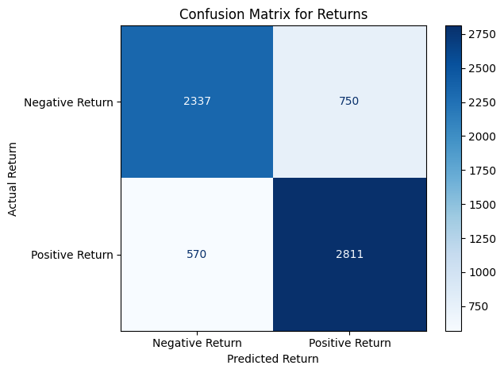

```python
print("Confusion Matrix")
print(confusion_matrix(y, ypred))
disp = ConfusionMatrixDisplay.from_predictions(y, ypred,
                              display_labels =["Negative Return","Positive Return"],
                                              cmap = plt.cm.Blues)
plt.title("Confusion Matrix for Returns")
plt.xlabel("Predicted Return")
plt.ylabel("Actual Return")
plt.tight_layout()
plt.show()
```

```python
print(classification_report(y, ypred, labels = ["0","1"]))
```

```
              precision    recall  f1-score   support

           0       0.80      0.76      0.78      3087
           1       0.79      0.83      0.81      3381

   micro avg       0.80      0.80      0.80      6468
   macro avg       0.80      0.79      0.79      6468
weighted avg       0.80      0.80      0.80      6468
```

## References

- [yfinance GitHub](https://github.com/ranaroussi/yfinance)
- [yfinance Documentation](https://ranaroussi.github.io/yfinance/)
- [Polars Online User Guide](https://docs.pola.rs/)
- [Build Polars Database](https://www.pyquantnews.com/free-python-resources/build-stock-database-locally-with-polars)
- [YouTube. Polars and Time Series: What It Can Do, and How to Overcome Any Limitation](https://www.youtube.com/watch?v=qz-zAHBz6Ks)
- [Awesome Quant: Python for Quantiative Finance](https://wilsonfreitas.github.io/awesome-quant/)
- [Cross-validation](https://scikit-learn.org/stable/modules/cross_validation.html)
- [TimeSeriesSplit](https://scikit-learn.org/stable/modules/generated/sklearn.model_selection.TimeSeriesSplit.html)
- [RandomizedSearchCV](https://scikit-learn.org/stable/modules/generated/sklearn.model_selection.RandomizedSearchCV.html)
- [Hyperparameter Tuning](https://scikit-learn.org/stable/modules/grid_search.html#grid-search)
- [Metrics and Scoring](https://scikit-learn.org/stable/modules/model_evaluation.html#scoring-parameter)
- [Introduction to Boosted Trees](https://xgboost.readthedocs.io/en/latest/tutorials/model.html)
- [XGBoost documentation](https://xgboost.readthedocs.io/en/latest/index.html)
- [XGBoost in Python documentation](https://xgboost-clone.readthedocs.io/en/latest/python/python_intro.html)
- [Auto-Sklearn for AutoML in an Scikit-Learn Environment](https://www.automl.org/automl-for-x/tabular-data/auto-sklearn/).